# YieldTrend10yrs - sharable

Pannaree Boonyuen

15 November, 2023

This is only the part where it is not confidential.

# Background

This is descriptive statistics of data from the original Thai document in Office of Agricultural Economics website is named พันธุ์ข้าวนาปี : เนื้อที่เพาะปลูก ผลผลิต และผลผลิตต่อไร่ รายจังหวัด ปีเพาะปลูก, appeared as in [this example file from the year 2022](https://www.oae.go.th/assets/portals/1/fileups/prcaidata/files/rice%20varieties%2064.pdf) in a section called ตารางแสดงรายละเอียดข้าวนาปี.

# Part A: Raw Data Processing

## Import

Import the raw data sheets (seperate sheet for each year), join them to make one data frame and raname the columns so that they are without whitespaces.

```r
library(readr)
library(tidyverse)
library(lava)
library(RColorBrewer)
library(ggplot2)

THRiceYieldpnv2021 <-
  read_csv(
    "data/raw-data/[Raw]_Thailand rice yield data by provice and variety 2012-2021 - 2021.csv"
  )
THRiceYieldpnv2020 <-
  read_csv(
    "data/raw-data/[Raw]_Thailand rice yield data by provice and variety 2012-2021 - 2020.csv"
  )
THRiceYieldpnv2019 <-
  read_csv(
    "data/raw-data/[Raw]_Thailand rice yield data by provice and variety 2012-2021 - 2019.csv"
  )
THRiceYieldpnv2018 <-
  read_csv(
    "data/raw-data/[Raw]_Thailand rice yield data by provice and variety 2012-2021 - 2018.csv"
  )
THRiceYieldpnv2017 <-
  read_csv(
    "data/raw-data/[Raw]_Thailand rice yield data by provice and variety 2012-2021 - 2017.csv"
  )
THRiceYieldpnv2016 <-
  read_csv(
    "data/raw-data/[Raw]_Thailand rice yield data by provice and variety 2012-2021 - 2016.csv"
  )
THRiceYieldpnv2015 <-
  read_csv(
    "data/raw-data/[Raw]_Thailand rice yield data by provice and variety 2012-2021 - 2015.csv"
  )
THRiceYieldpnv2014 <-
  read_csv(
    "data/raw-data/[Raw]_Thailand rice yield data by provice and variety 2012-2021 - 2014.csv"
  )
THRiceYieldpnv2013 <-
  read_csv(
    "data/raw-data/[Raw]_Thailand rice yield data by provice and variety 2012-2021 - 2013.csv"
  )
THRiceYieldpnv2012 <-
  read_csv(
    "data/raw-data/[Raw]_Thailand rice yield data by provice and variety 2012-2021 - 2012.csv"
  )
THRiceYieldpnv10yrs <-
  rbind(
    THRiceYieldpnv2012,
    THRiceYieldpnv2013,
    THRiceYieldpnv2014,
    THRiceYieldpnv2015,
    THRiceYieldpnv2016,
    THRiceYieldpnv2017,
    THRiceYieldpnv2018,
    THRiceYieldpnv2019,
    THRiceYieldpnv2020,
    THRiceYieldpnv2021
  )
names(THRiceYieldpnv10yrs) <-
  c(
    "year",
    "province",
    "variety",
    "plantingarea",
    "harvestedarea",
    "production",
    "YieldPA",
    "YieldHA",
    "portionplant"
  )
```

## Check summary and Remove Missing Data

Check how it looks like and whether there is any missing data (NA)

```r
#How it look like
head(THRiceYieldpnv10yrs)
```

```
## # A tibble: 6 × 9
##    year province   variety       plant…¹ harve…² produ…³ YieldPA YieldHA porti…⁴
##   <dbl> <chr>      <chr>           <dbl>   <dbl>   <dbl>   <dbl>   <dbl>   <dbl>
## 1  2012 Chiang Rai NativeRice      56793   56354   29929     527     531    4.2
## 2  2012 Chiang Rai RD6            928946  920803  562722     606     611   68.7
## 3  2012 Chiang Rai RD15           126462  126135   76741     607     608    9.35
## 4  2012 Chiang Rai KDML105         95452   95029   60025     629     632    7.06
## 5  2012 Chiang Rai SuphanBuri60    13060   13060    9218     706     706    0.97
## 6  2012 Chiang Rai PhotoperiodS…   25737   25737   19348     752     752    1.9
## # … with abbreviated variable names ¹plantingarea, ²harvestedarea, ³production,
## #   ⁴portionplant
```

```r
#What overall data composed of
summary(THRiceYieldpnv10yrs)
```

```
##       year        province           variety           plantingarea
##  Min.   :2012   Length:6775        Length:6775        Min.   :      0
##  1st Qu.:2015   Class :character   Class :character   1st Qu.:      0
##  Median :2018   Mode  :character   Mode  :character   Median :   5868
##  Mean   :2017                                         Mean   :  90106
##  3rd Qu.:2020                                         3rd Qu.:  43252
##  Max.   :2021                                         Max.   :3038828
##  NA's   :1                                            NA's   :1
##  harvestedarea       production         YieldPA         YieldHA
##  Min.   :      0   Min.   :      0   Min.   :  0.0   Min.   :  0.0
##  1st Qu.:      0   1st Qu.:      0   1st Qu.:  0.0   1st Qu.:  0.0
##  Median :   5640   Median :   2620   Median :374.0   Median :389.0
##  Mean   :  84418   Mean   :  38020   Mean   :347.2   Mean   :357.8
##  3rd Qu.:  41706   3rd Qu.:  20338   3rd Qu.:531.0   3rd Qu.:544.8
##  Max.   :2889505   Max.   :1027710   Max.   :899.0   Max.   :899.0
##  NA's   :1         NA's   :1         NA's   :1       NA's   :1
##   portionplant
##  Min.   :  0.00
##  1st Qu.:  0.00
##  Median :  1.78
##  Mean   : 11.37
##  3rd Qu.: 10.90
##  Max.   :100.00
##  NA's   :1
```

```r
#how many missing dates
sum(is.na(THRiceYieldpnv10yrs)) #there are 9 missing values (NA)
```

```
## [1] 9
```

```r
#check where there are in an array-based index
which(is.na.data.frame(THRiceYieldpnv10yrs), arr.ind    = TRUE) #there are from the same row
```

```
##        row col
##  [1,] 2009   1
##  [2,] 2009   2
##  [3,] 2009   3
##  [4,] 2009   4
##  [5,] 2009   5
##  [6,] 2009   6
##  [7,] 2009   7
##  [8,] 2009   8
##  [9,] 2009   9
```

```r
#easily remove it out
THRiceYieldpnv10yrs <-
  THRiceYieldpnv10yrs %>% filter(!is.na(year))
#recheck
sum(is.na(THRiceYieldpnv10yrs)) #there are no NA's
```

```
## [1] 0
```

## Add “region” variable and change too-long variety name

To aid the search for trends, we add the region of province from which each observation was recorded. The region is defined geographically. The total number of provinces = 77, divided into 6 regions: NorthEast, North, South, Central, East, anก West.

```r
region_provincelist <- read_csv("data/raw-data/region-provincellsit.csv",col_names = F)
NorthEast<- region_provincelist[1,2]
North <- region_provincelist[2,2]
South <- region_provincelist[3,2]
Central <- region_provincelist[4,2]
East <- region_provincelist[5,2]
West <- region_provincelist[6,2]

#remove whitespaces and split them into individual provinces with the function below
library(stringr)
FormProvinceStr <- function(Listcomma) {
  Listcomma <- str_replace_all(Listcomma, " ", "")
  Listcomma2 <- str_split(Listcomma, ",", simplify = TRUE)
  return(Listcomma2)
}
#use with each list
North <- FormProvinceStr(North)
NorthEast <- FormProvinceStr(NorthEast)
South <- FormProvinceStr(South)
Central <- FormProvinceStr(Central)
East <- FormProvinceStr(East)
West <- FormProvinceStr(West)
#create the province list for future's use
provinceList <- c(NorthEast, North, South, Central, East, West)
provinceList <-
  provinceList[order(c(NorthEast, North, South, Central, East, West))] #order alphabetically

#also remove whitespaces from "province" column of THRiceYieldpnv10yrs to make it match the lists
THRiceYieldpnv10yrs$province <-
  str_replace_all(THRiceYieldpnv10yrs$province, " ", "")

#use mutate + case_when to add the correct region to each observation
RegTHRiceYieldpnv10yrs <- THRiceYieldpnv10yrs %>%
  mutate(
    region = case_when(
      match(province, NorthEast) > 0 ~ "NorthEast",
      match(province, North) > 0 ~ "North",
      match(province, South) > 0 ~ "South",
      match(province, Central) > 0 ~ "Central",
      match(province, East) > 0 ~ "East",
      match(province, West) > 0 ~ "West",
      TRUE ~ "CheckSpell"
    )
  )

which(RegTHRiceYieldpnv10yrs$region == "CheckSpell", arr.ind = TRUE)
```

```
## integer(0)
```

```r
#no data has not found a match

#and change too-long variety names: NonPhotoperiodSensitiveRice, PhotoperiodSensitiveRice, SupanburiAromaticRice
RegTHRiceYieldpnv10yrs$variety[which(RegTHRiceYieldpnv10yrs$variety == "NonPhotoperiodSensitiveRice")] <-
  "NonPhotoSens"
RegTHRiceYieldpnv10yrs$variety[which(RegTHRiceYieldpnv10yrs$variety == "PhotoperiodSensitiveRice")] <-
  "PhotoSens"
RegTHRiceYieldpnv10yrs$variety[which(RegTHRiceYieldpnv10yrs$variety == "SupanburiAromaticRice")] <-
  "SuphanAromatic"

#Make a variety list and a focused variety list, which are the varieties we have collected the data for in the past and established the standard practice for
varlist <- unlist(distinct(as.data.frame(RegTHRiceYieldpnv10yrs$variety)), use.names = F)
focusedvar <- c("PTT1", "KDML105", "RD6", "NonPhotoSens")
```

## Remove “planting area = 0”

- There is inconsistency in data recording practices. Before 2017, they did not record a variety that a province did not grow; however, after 2017, they recorded all 12 varieties for all provinces and added “planting area = 0” for a variety that was not grown in that province (which means “yield = 0” was also added). Hence, calculating the mean yield using the mean() function showed a drastic drop after year 2017 (“yield=0” was interpreted as if the yield was 0, but in fact, the planting area is 0): see the first graph.
- We only need calculate the mean yields from the provinces with growers, so we decided to remove the observation with planting area = 0. After processing, the means were more stable: see the second graph.

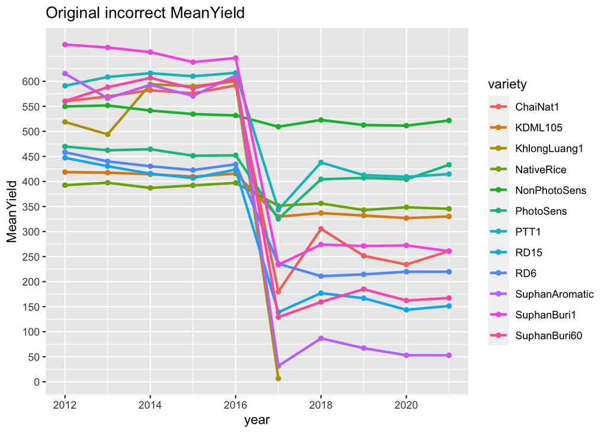

```r
#Original incorrect MeanYield
RegTHRiceYieldpnv10yrs %>% group_by(variety, year) %>% summarise(MeanYield = mean(YieldHA)) %>%
  ggplot() +
  geom_point(mapping = aes(y = MeanYield, x = year, col = variety),
             size = 1.5) +
  geom_line(mapping = aes(y = MeanYield, x = year, col = variety),
            size = 1) +
  scale_y_continuous(breaks = seq(0, 600, by = 50)) +
  labs(title = "Original incorrect MeanYield")
```

```r
RegTHRiceYieldpnv10yrs %>% filter(plantingarea == 0)
```

```
## # A tibble: 1,811 × 10
##     year province variety plant…¹ harve…² produ…³ YieldPA YieldHA porti…⁴ region
##    <dbl> <chr>    <chr>     <dbl>   <dbl>   <dbl>   <dbl>   <dbl>   <dbl> <chr>
##  1  2017 ChiangR… ChaiNa…       0       0       0       0       0       0 North
##  2  2017 ChiangR… Khlong…       0       0       0       0       0       0 North
##  3  2017 ChiangR… Suphan…       0       0       0       0       0       0 North
##  4  2017 Phayao   Suphan…       0       0       0       0       0       0 North
##  5  2017 Phayao   ChaiNa…       0       0       0       0       0       0 North
##  6  2017 Phayao   Khlong…       0       0       0       0       0       0 North
##  7  2017 Phayao   Suphan…       0       0       0       0       0       0 North
##  8  2017 Phayao   PTT1          0       0       0       0       0       0 North
##  9  2017 Phayao   Suphan…       0       0       0       0       0       0 North
## 10  2017 Lampang  Suphan…       0       0       0       0       0       0 North
## # … with 1,801 more rows, and abbreviated variable names ¹plantingarea,
## #   ²harvestedarea, ³production, ⁴portionplant
```

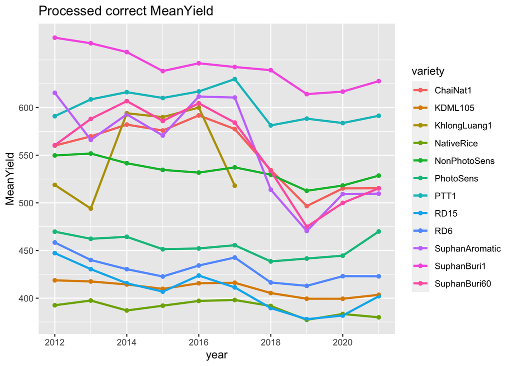

```r
#there are 1811 rows with planting area = 0. All of them produced in 2017 onwards.

#remove planting area ==0
RegTHRiceYieldpnv10yrs <- RegTHRiceYieldpnv10yrs %>% filter(plantingarea != 0)

#New plot
RegTHRiceYieldpnv10yrs %>% group_by(variety, year) %>% summarise(MeanYield = mean(YieldHA)) %>%
  ggplot() +
  geom_point(mapping = aes(y = MeanYield, x = year, col = variety),
             size = 1.5) +
  geom_line(mapping = aes(y = MeanYield, x = year, col = variety),
            size = 1) +
  scale_y_continuous(breaks = seq(0, 600, by = 50)) +
  labs(title = "Processed correct MeanYield")
```

# Part B: Trend of Production and Popularity

## Trend of all varieties, whole-country

The plots show the sum of either production (1.1 and 2.1) or planting area (1.2 and 2.2) of rice of each variety, produced across the country each year (yearly totoal production in tons and yearly total planting area in rais). Part 1 is for all varieties, and part 2 is for focused varieties.

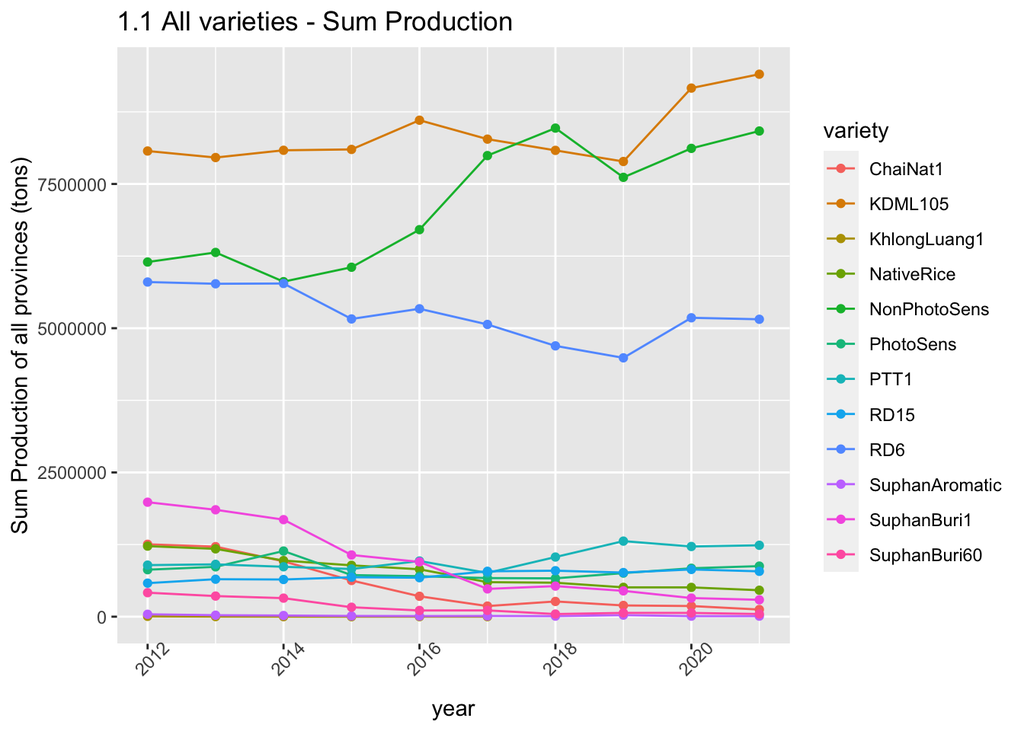

```r
RegTHRiceYieldpnv10yrs %>% group_by(variety, year) %>% summarise(totProd = sum(production)) %>%
  ggplot() +
  geom_line(mapping = aes(x = year, y = totProd, col = variety)) +
  geom_point(mapping = aes(x = year, y = totProd, col = variety)) +
  theme(axis.text.x = element_text(angle = 45)) +
  labs(y = "Sum Production of all provinces (tons)",  title = "1.1 All varieties - Sum Production")
```

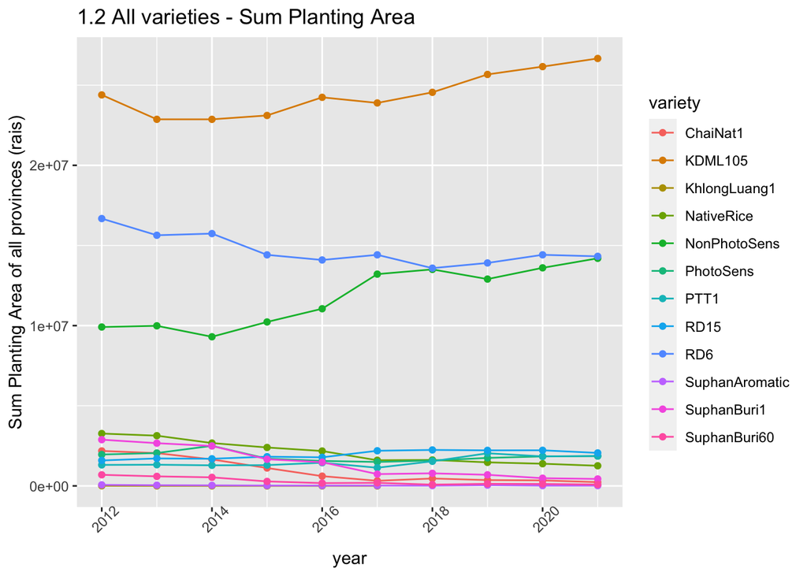

```r
RegTHRiceYieldpnv10yrs %>% group_by(variety, year) %>% summarise(totPop = sum(plantingarea)) %>%
  ggplot() +
  geom_line(mapping = aes(x = year, y = totPop, col = variety)) +
  geom_point(mapping = aes(x = year, y = totPop, col = variety)) +
  theme(axis.text.x = element_text(angle = 45)) +
  labs(y = "Sum Planting Area of all provinces (rais)",  title = "1.2 All varieties - Sum Planting Area")
```

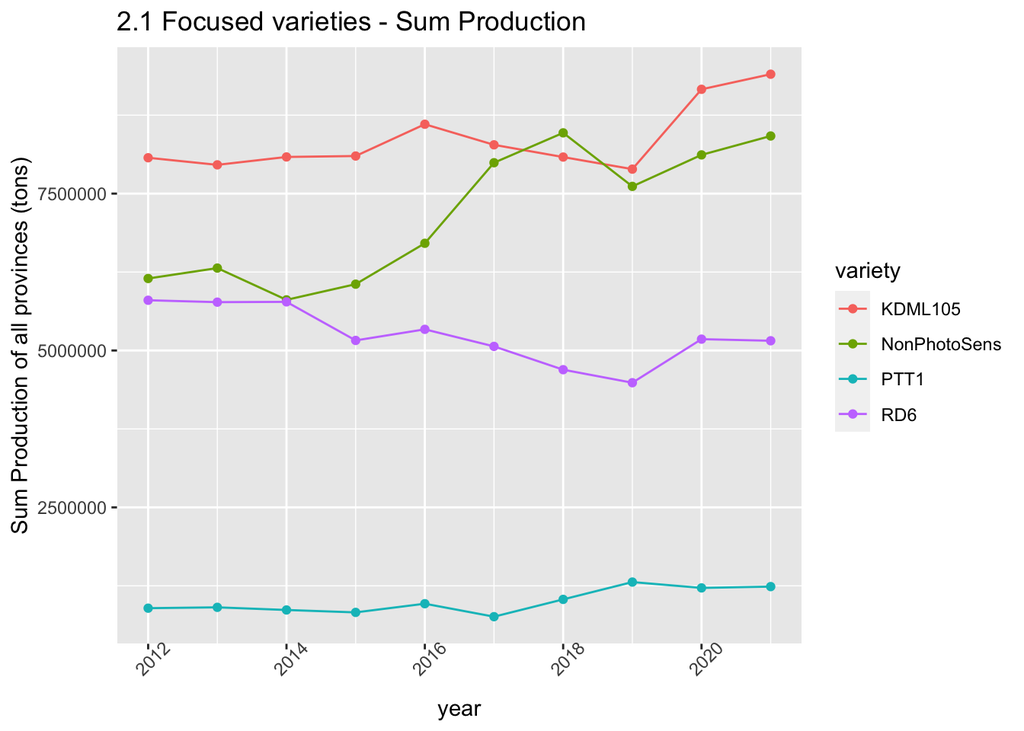

```r
#focused var only
RegTHRiceYieldpnv10yrs %>% filter(variety %in% focusedvar) %>% group_by(variety, year) %>% summarise(totProd = sum(production)) %>%
  ggplot() +
  geom_line(mapping = aes(x = year, y = totProd, col = variety)) +
  geom_point(mapping = aes(x = year, y = totProd, col = variety)) +
  theme(axis.text.x = element_text(angle = 45)) +
  labs(y = "Sum Production of all provinces (tons)", title = "2.1 Focused varieties - Sum Production")
```

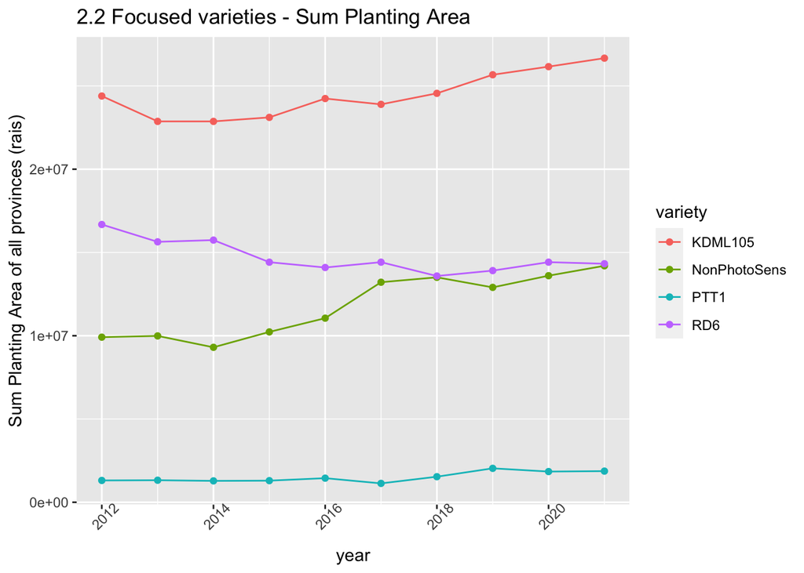

```r
RegTHRiceYieldpnv10yrs %>% filter(variety %in% focusedvar) %>% group_by(variety, year) %>% summarise(totPop = sum(plantingarea)) %>%
  ggplot() +
  geom_line(mapping = aes(x = year, y = totPop, col = variety)) +
  geom_point(mapping = aes(x = year, y = totPop, col = variety)) +
  theme(axis.text.x = element_text(angle = 45)) +
  labs(y = "Sum Planting Area of all provinces (rais)", title = "2.2 Focused varieties - Sum Planting Area")
```

Looking closer into fig 2.1, * KDML105 had been the most produced variety of in-season rice in Thailand in all years from 2012-2021, followed by non-photoperiod sensitive rice. Only in 2018 did they switch places. * The third most produced was RD6. PTT1 was much less produced, only reach the top of 1,250,000 tons in year 2019, approximately 7 times lower than that of KDML105.

**These are the whole-country stats, so later, we would zoom into a smaller scale, a region, to understand further at the trend of production and popularity for the focused varieties.**

## Trend of focused varieties, regional

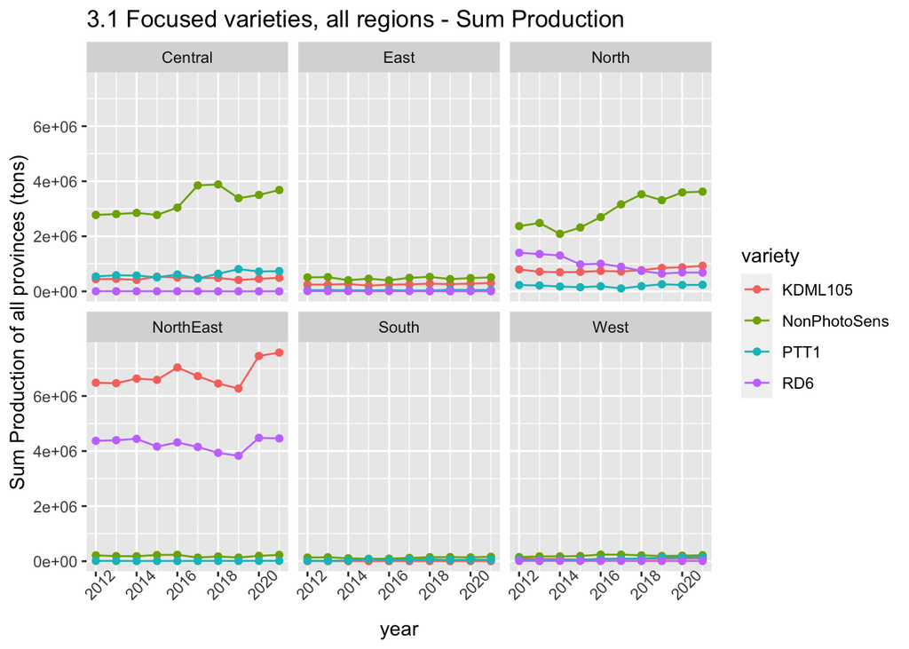

```r
RegTHRiceYieldpnv10yrs %>% filter(variety %in% focusedvar) %>% group_by(variety, region, year) %>% summarise(totProd = sum(production))  %>%
  ggplot() +
  geom_line(mapping = aes(x = year, y = totProd, col = variety)) +
  facet_wrap(~region) +
  geom_point(mapping = aes(x = year, y = totProd, col = variety)) +
  theme(axis.text.x = element_text(angle = 45)) +
  labs(y = "Sum Production of all provinces (tons)", title = "3.1 Focused varieties, all regions - Sum Production")
```

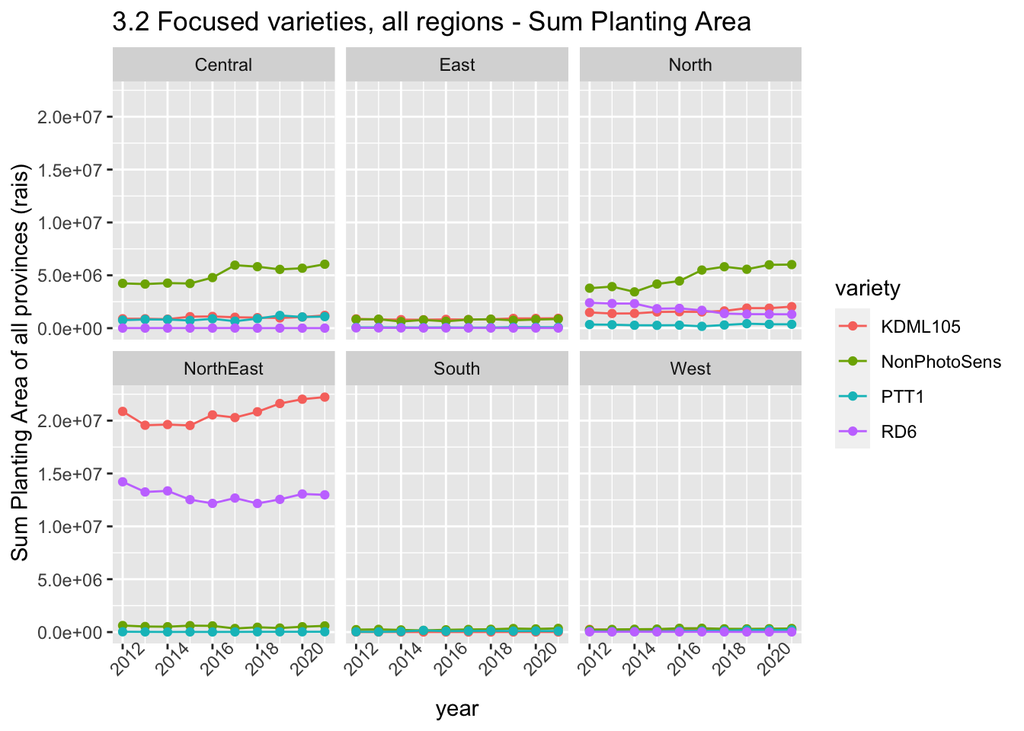

```r
RegTHRiceYieldpnv10yrs %>% filter(variety %in% focusedvar) %>% group_by(variety, region, year) %>% summarise(totPop = sum(plantingarea))  %>%
  ggplot() +
  geom_line(mapping = aes(x = year, y = totPop, col = variety)) +
  facet_wrap(~region) +
  geom_point(mapping = aes(x = year, y = totPop, col = variety)) +
  theme(axis.text.x = element_text(angle = 45)) +
  labs(y = "Sum Planting Area of all provinces (rais)", title = "3.2 Focused varieties, all regions - Sum Planting Area")
```

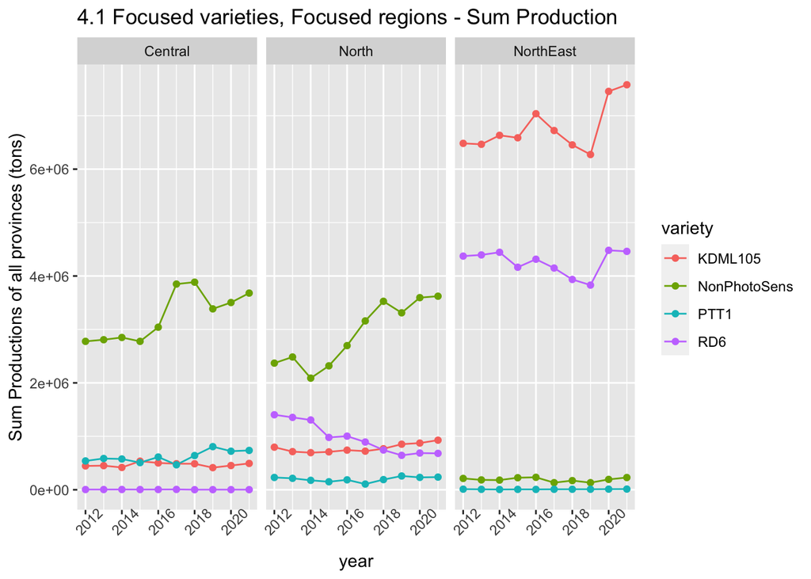

```r
RegTHRiceYieldpnv10yrs %>% filter(variety %in% focusedvar) %>% group_by(region, variety, year) %>% summarise(totProd = sum(production)) %>% filter(region %in% c("Central", "North", "NorthEast")) %>%
  ggplot() +
  geom_line(mapping = aes(x = year, y = totProd, col = variety)) +
  geom_point(mapping = aes(x = year, y = totProd, col = variety)) +
  facet_wrap(~region) +
  theme(axis.text.x = element_text(angle = 45)) +
  labs(y = "Sum Productions of all provinces (tons)", title = "4.1 Focused varieties, Focused regions - Sum Production")
```

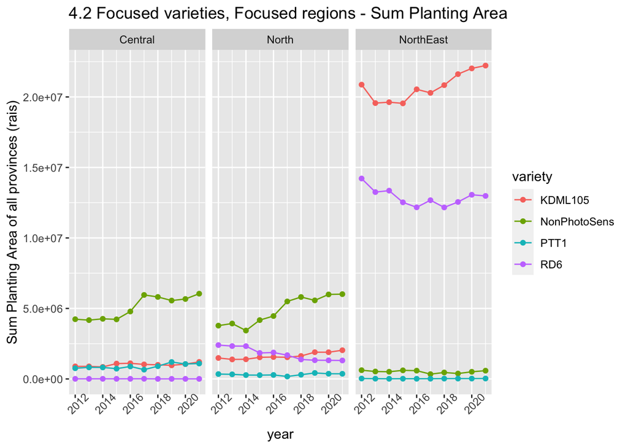

```r
RegTHRiceYieldpnv10yrs %>% filter(variety %in% focusedvar) %>% group_by(region, variety, year) %>% summarise(totProd = sum(plantingarea)) %>% filter(region %in% c("Central", "North", "NorthEast")) %>%
  ggplot() +
  geom_line(mapping = aes(x = year, y = totProd, col = variety)) +
  geom_point(mapping = aes(x = year, y = totProd, col = variety)) +
  facet_wrap(~region) +
  theme(axis.text.x = element_text(angle = 45)) +
  labs(y = "Sum Planting Area of all provinces (rais)", title = "4.2 Focused varieties, Focused regions - Sum Planting Area")
```

* From 3.1 and 3.2, NorthEast, Central and North planted and produced dominant amount of some varieties that are in our focus, so we looked into these three regions for the focused varieties in fig 4.1-4.2. * From fig 4.1-4.2, Central and North produced and grew non-photoperiod sensitive rice the most, while in NorthEast, KDML105 and RD6 were much more produced and grown. PTT1 was most produced and planted in Central.

- These show that if we are to choose the regions of study for yield modelling and practice improvement, the best options to potentially obtain a large number of data and to produce the most impact from the study are the following: Central or North provinces for non-photoperiod sensitive rice, Central for PTT1 and Northeast for KDML105 and RD6.

# Part C: Trend of Yield

## Trend of all varieties, whole-country

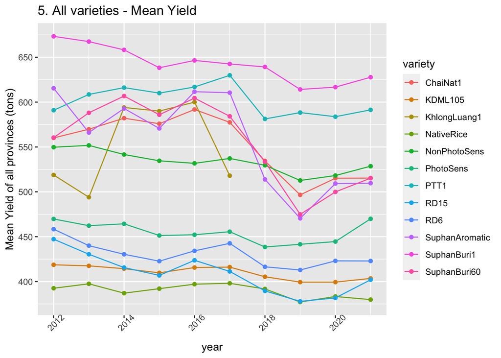

```r
RegTHRiceYieldpnv10yrs %>% group_by(variety, year) %>% summarise(meanY = mean(YieldHA)) %>%
  ggplot() +
  geom_line(mapping = aes(x = year, y = meanY, col = variety)) +
  geom_point(mapping = aes(x = year, y = meanY, col = variety)) +
  theme(axis.text.x = element_text(angle = 45)) +
  scale_y_continuous(breaks = seq(300, 800, by = 50)) +
  labs(y = "Mean Yield of all provinces (tons)",  title = "5. All varieties - Mean Yield")
```

```r
#table below show the number from the lastest year (2021)
RegTHRiceYieldpnv10yrs %>% filter(year == 2021) %>%  group_by(variety) %>% summarise(meanY = mean(YieldHA))
```

```
## # A tibble: 11 × 2
##    variety        meanY
##    <chr>          <dbl>
##  1 ChaiNat1        515.
##  2 KDML105         403.
##  3 NativeRice      380.
##  4 NonPhotoSens    529.
##  5 PhotoSens       470.
##  6 PTT1            591.
##  7 RD15            402
##  8 RD6             423.
##  9 SuphanAromatic  510.
## 10 SuphanBuri1     628.
## 11 SuphanBuri60    515.
```

## Trend of focused variety, regional

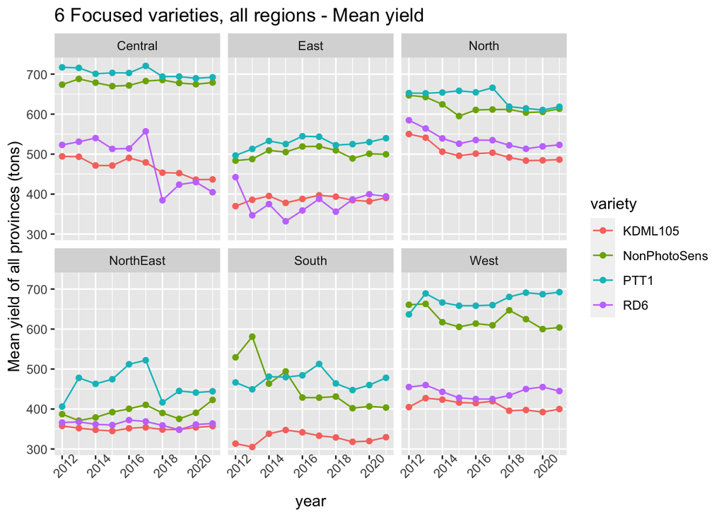

```r
RegTHRiceYieldpnv10yrs %>% filter(variety %in% focusedvar) %>% group_by(variety, region, year) %>% summarise(MeanY = mean(YieldHA))  %>%
  ggplot() +
  geom_line(mapping = aes(x = year, y = MeanY, col = variety)) +
  facet_wrap(~region) +
  geom_point(mapping = aes(x = year, y = MeanY, col = variety)) +
  theme(axis.text.x = element_text(angle = 45)) +
  labs(y = "Mean yield of all provinces (tons)", title = "6 Focused varieties, all regions - Mean yield")
```

- Separated into regional yields, as expected, in all regions, KDML105 and RD6 gave the lower yields than PTT1 and other NonPhotoSens. Central and North, where PTT1 and NonPhotoSens was grown the most, gave best yields of PTT1 and NonPhotoSens.
- One major takeaway is that NE is the regions where all these varieties were doing worst (except KDML105 planted in Southern part that gave the worst yields of less than 350 kg/rai): RD6 and KDML105 were lower in yield than the other two as well. West, although not a major grower or producer, gave impressive yields of NonPhotoSens and PTT1.
- These again show that NE is the area that suffer from non-effective agricultural practices, despite being the top grower and producer, especially for KDML105 and RD6 farmers. KDML105, being sold at a higher price than other varities, may be chosen because of economic return by the NE farmers, so they may still have profit, but improving yields even 1% in these areas would lead to a high impact due to a large planting area in NE. On the other hand, Central and North are two best producers for all focused varieties, so these can be used as the “Model regions” for NE to follow the management that works well there.

# Part D: All-time Popularity, Production, Yield

We will search for the order of top provinces in each aspect for each variety (Top grower, Top producer, Best producer). The stats are calculate from all years, aka means from 10 years, from 2012-2021.

## Creating Functions

Top grower of each variety = province/region that has the largest area (in rai) for that variety. Top producer of each variety = province/region that has the highest production (in ton) for that variety. Best producer of each variety = province/region that has the most yield from harvested area (in kg/rai) for that variety. The functions calculate the means of all years (2012-2021).

```r
FindTopGrower <-
  function(var, scale,  yr = "all",fromtop = T) {
    #var is variety, scale can be provincial (1) or regional (2), n is the return size of top list
    if (var == "all") {
      current <-
          RegTHRiceYieldpnv10yrs
    }else if (var %ni% varlist) {
      print(
        "check the spelling of your variety. They must be one of the following: NativeRice, RD6, RD15, KDML105, SuphanBuri60, PhotoSens, NonPhotoSens, ChaiNat1, PTT1, SuphanBuri1, SuphanAromatic, KhlongLuang1"
      )
    } else{
      current <-
          RegTHRiceYieldpnv10yrs %>% filter(variety == var)
      print(paste0(nrow(current), " is the row number after variety is filtered"))
    }

    if (yr != "all"){
      current <- current %>% filter(year == yr)
      print("year is filtered")
      print(paste0(nrow(current), " is the row number after year is filtered"))
    }

    if (scale == 1) {
        TopProvince <-
          current %>% group_by(province, region) %>% summarise(MeanPA = mean(plantingarea))
        return(TopProvince[order(TopProvince$MeanPA, decreasing = fromtop), ])
    } else if (scale == 2) {
        TopRegion <-
          current %>% group_by(region, year) %>% summarise(sumPA = sum(plantingarea)) %>% group_by(region) %>% summarise(MeansumPA = mean(sumPA))
        return(TopRegion[order(TopRegion$MeansumPA, decreasing = fromtop), ])
    } else{
        print("Check that the scale is either provincial (1) or regional (2).")
    }

  }
#test
FindTopGrower("KDML105", scale = 1, "all")
```

```
## [1] "623 is the row number after variety is filtered"
```

```
## # A tibble: 70 × 3
## # Groups:   province [70]
##    province         region      MeanPA
##    <chr>            <chr>        <dbl>
##  1 NakhonRatchasima NorthEast 2857070.
##  2 SiSaKet          NorthEast 2638422
##  3 BuriRam          NorthEast 2533651.
##  4 Surin            NorthEast 2453351.
##  5 UbonRatchathani  NorthEast 2261310.
##  6 RoiEt            NorthEast 2191601.
##  7 MahaSarakham     NorthEast 1044190.
##  8 Chaiyaphum       NorthEast  797162.
##  9 Yasothon         NorthEast  769332
## 10 NakhonSawan      Central    655822.
## # … with 60 more rows
```

```r
FindTopGrower("all", scale = 2, "all")
```

```
## # A tibble: 6 × 2
##   region    MeansumPA
##   <chr>         <dbl>
## 1 NorthEast 37494352.
## 2 North     10808673.
## 3 Central    8302478.
## 4 East       2325826.
## 5 West       1281709.
## 6 South       824854.
```

```r
FindTopGrower("all", scale = 1, "all")
```

```
## # A tibble: 77 × 3
## # Groups:   province [77]
##    province         region     MeanPA
##    <chr>            <chr>       <dbl>
##  1 UbonRatchathani  NorthEast 639560.
##  2 Surin            NorthEast 564675.
##  3 RoiEt            NorthEast 452645.
##  4 SiSaKet          NorthEast 448487.
##  5 BuriRam          NorthEast 411434.
##  6 KhonKaen         NorthEast 368212.
##  7 SakonNakhon      NorthEast 332556.
##  8 NakhonRatchasima NorthEast 329153.
##  9 MahaSarakham     NorthEast 302920.
## 10 UdonThani        NorthEast 294134.
## # … with 67 more rows
```

```r
# FindTopGrower("wrongvariety", scale = 2)
# FindTopGrower("KDML105", scale = 3)
```

```r
FindTopProducer <-
  function(var, scale,  yr = "all",fromtop = T) {
    #var is variety, scale can be provincial (1) or regional (2), n is the return size of top list
    if (var == "all") {
      current <-
          RegTHRiceYieldpnv10yrs
    }else if (var %ni% varlist) {
      print(
        "check the spelling of your variety. They must be one of the following: NativeRice, RD6, RD15, KDML105, SuphanBuri60, PhotoSens, NonPhotoSens, ChaiNat1, PTT1, SuphanBuri1, SuphanAromatic, KhlongLuang1"
      )
    } else{
      current <-
          RegTHRiceYieldpnv10yrs %>% filter(variety == var)
      print(paste0(nrow(current), " is the row number after variety is filtered"))
    }

    if (yr != "all"){
      current <- current %>% filter(year == yr)
      print("year is filtered")
      print(paste0(nrow(current), " is the row number after year is filtered"))
    }

    if (scale == 1) {
        TopProvince <-
          current %>% group_by(province, region) %>% summarise(MeanProd = mean(production))
        print(paste0(nrow(current), " is the row number after whne the scale is selected"))
        return(TopProvince[order(TopProvince$MeanProd, decreasing = fromtop), ])
      } else if (scale == 2) {
        TopRegion <-
          current %>% group_by(region, year) %>% summarise(sumProd = sum(production)) %>% group_by(region) %>% summarise(MeansumProd = mean(sumProd))
        return(TopRegion[order(TopRegion$MeansumProd, decreasing = fromtop), ])
      } else{
        print("Check that the scale is either provincial (1) or regional (2).")
      }


  }
#test
FindTopProducer("all", scale = 1, yr = "all")
```

```
## [1] "4963 is the row number after whne the scale is selected"
```

```
## # A tibble: 77 × 3
## # Groups:   province [77]
##    province        region    MeanProd
##    <chr>           <chr>        <dbl>
##  1 UbonRatchathani NorthEast  213970.
##  2 Surin           NorthEast  201782.
##  3 SiSaKet         NorthEast  155493.
##  4 RoiEt           NorthEast  147080.
##  5 SuphanBuri      Central    146650.
##  6 BuriRam         NorthEast  136389.
##  7 NakhonSawan     Central    129098.
##  8 SakonNakhon     NorthEast  106869.
##  9 KhonKaen        NorthEast  104396.
## 10 UdonThani       NorthEast  103526.
## # … with 67 more rows
```

```r
FindTopProducer("all", scale = 2, yr =  "all")
```

```
## # A tibble: 6 × 2
##   region    MeansumProd
##   <chr>           <dbl>
## 1 NorthEast   12379489.
## 2 North        6055509.
## 3 Central      5144464.
## 4 East         1054993.
## 5 West          757178.
## 6 South         363239.
```

```r
FindTopProducer("all", scale = 1, yr =  2021)
```

```
## [1] "year is filtered"
## [1] "507 is the row number after year is filtered"
```

```
## [1] "507 is the row number after whne the scale is selected"
```

```
## # A tibble: 77 × 3
## # Groups:   province [77]
##    province        region    MeanProd
##    <chr>           <chr>        <dbl>
##  1 UbonRatchathani NorthEast  239349.
##  2 Surin           NorthEast  191531.
##  3 BuriRam         NorthEast  152482.
##  4 RoiEt           NorthEast  147553.
##  5 SuphanBuri      Central    138950.
##  6 SiSaKet         NorthEast  128380.
##  7 NakhonSawan     Central    127464.
##  8 KhonKaen        NorthEast  118211
##  9 SakonNakhon     NorthEast  107863.
## 10 UdonThani       NorthEast  107093.
## # … with 67 more rows
```

```r
FindTopProducer("KDML105", scale = 1, yr =  "all")
```

```
## [1] "623 is the row number after variety is filtered"
```

```
## [1] "623 is the row number after whne the scale is selected"
```

```
## # A tibble: 70 × 3
## # Groups:   province [70]
##    province         region    MeanProd
##    <chr>            <chr>        <dbl>
##  1 SiSaKet          NorthEast  909219.
##  2 Surin            NorthEast  874635.
##  3 NakhonRatchasima NorthEast  838790.
##  4 BuriRam          NorthEast  833539.
##  5 UbonRatchathani  NorthEast  749768.
##  6 RoiEt            NorthEast  706201
##  7 MahaSarakham     NorthEast  343281.
##  8 NakhonSawan      Central    323683.
##  9 Yasothon         NorthEast  254807.
## 10 Chaiyaphum       NorthEast  242308.
## # … with 60 more rows
```